# Multiple Comparisons

## Key ideas

- Hypothesis testing/significance analysis is commonly overused
- Correcting for multiple testing avoids false positives or discoveries
- Two key components
  - Error measure
  - Correction

## Three eras of statistics

**The ages of Quetelet and his successors, in which huge census-level data sets were brought to bear on simple but important questions**: Are there more male than female births? Is the rate of insanity rising?

The classical period of Pearson, Fisher, Neyman, Hotelling, and their succcessors, intellectual giants who **developed a theory of optimal inference capable of wringing every drop of information out of a scientific experiment.** The questions dealt with still tended to be simple. Is treatment A better than treatment B?

**The era of scientific mass production**, in which new technologies typified by the microarray allow a single team of scientists to produce data sets of a size Quetelet would envy. But now the flood of data is accompanied by a deluge of questions, perhaps thousands of estimates or hypothesis tests that the statistician is charged with answering together; not at all what the classical masters had in mind. Which variables matter among the thousands measured? how do you related unrelated information?

http://www-stat.stanford.edu/~ckirby/brad/papers/2010LSIexcerpt.pdf

## Reasons for multiple testing

[figure not shown]

## Why correct for multiple tests?

[figure not shown]

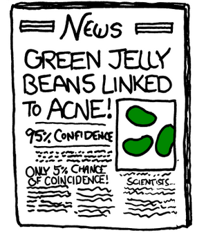

https://xkcd.com/882/

## Types of errors

Suppose you are testing a hyopthesis that a parameter $\beta$ equals zero versus the alternative that it does not equal zero. These are the possible outcomes.

|  | $\beta =0$ | $\beta \ne 0$ | **HYPOTHESIS** |
| --- | --- | --- | --- |
| **Claim** $\beta =0$ | $U$ | $T$ | $m-R$ |
| **Claim** $\beta \ne 0$ | $V$ | $S$ | $R$ |
| **Claims** | $m_0$ | $m-m_0$ | $m$ |

**Type I error or false positive (V)** Say that the parameter does not equal zero when it does

**Type II error or false negative (T)** Say that the parameter equals zero when it doesn’t

## Error rates

**False positive rate -** The rate at which false results ($\beta =0$) are called significant: $E\left[\frac{V}{m_0}\right]$ *

**Family wise error rate (FWER) -** The probability of at least one false positive $Pr(V \ge 1)$

**False discovery rate (FDR) -** The rate at which claims of significance are false $E\left[\frac{V}{R}\right]$

- The false positive rate is closely related to the type I error rate https://en.wikipedia.org/wiki/False_positive_rate

## Controlling the false positive rate

If P-values are correctly calculated calling all $P < \alpha$ significant will control the false positive rate at level $\alpha$ on average

Problem: Suppose that you perform 10,000 tests and $\beta$ = 0 for all of them

Suppose that you call all $P < 0.05$ significant

The expected number of false positives is: $10,000 \times 0.05 = 500$ false positives

**How do we avoid so many false positives?**

## Controlling family-wise error rate (FWER)

The [Bonferrroni correction](https://en.wikipedia.org/wiki/Bonferroni_correction) is the oldest multiple testing correction

**Basic idea:**

- Suppose you do $m$ tests
- You want to control FWER at level $\alpha$ so $Pr(V \ge 1) < \alpha$
- Calculate P-values normally
- Set $\alpha_{fwer} = \alpha /m$
- Call all P-values less than $\alpha_{fwer}$ significant

**Pros:** Easy to calculate, conservative **Cons:** May be very conservative

## Controlling false discovery rate (FDR)

This is the most popular correction when performing *lots* of tests, say, in genomic, imaging, astronomy, or other signal-processing disciplines

**Basic idea:**

- Suppose you do $m$ tests
- You want to control FDR at level $\alpha$ so $E\left[\frac{V}{R}\right]$
- Calculate P-values normally
- Order the P-values from smallest to largest $P_{(1)},...,P_{m}$
- Call any $P_{(i)} \le \alpha \times \frac{i}{m}$ significant

**Pros:** Still pretty easy to calculate, less conservative (maybe much less) **Cons:** Allows for more false positives, may behave strangely under dependence

## Example with 10 P-values

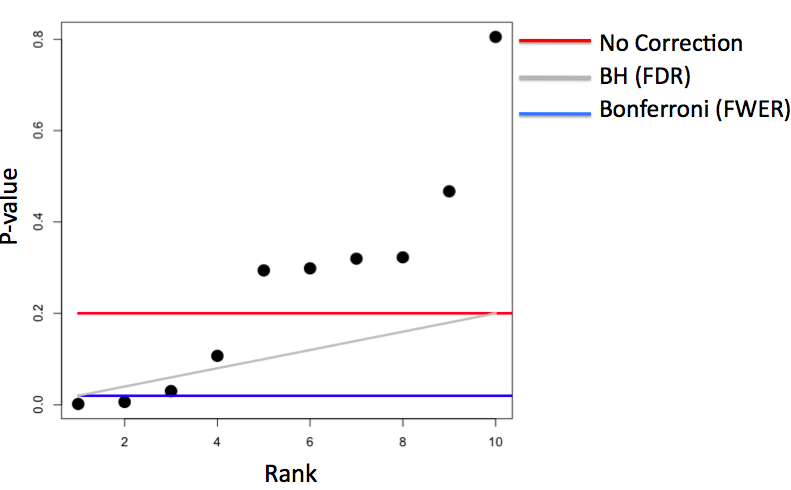

Controlling all error rates at $alpha = 0.20$

## Adjusting P-values

- One approach is to adjust the threshold $\alpha$
- A different approach is to calculate “adjusted p-values”
- They *are not p-values* anymore
- But they can be used directly without adjusting $\alpha$

**Example:**

## Case study I: no true positives

```r
set.seed(1010093)
pValues <- rep(NA, 1000)
for (i in 1:1000) {
    y <- rnorm(20)
    x <- rnorm(20)
    pValues[i] <- summary(lm(y ~ x))$coeff[2,4]
}

# Controls false positive rate
sum(pValues < 0.05)
```

```
## [1] 51
```

```r
# Controls FWER
sum(p.adjust(pValues, method="bonferroni") < 0.05)
```

```
## [1] 0
```

```r
# Controls FDR
sum(p.adjust(pValues, method="BH") < 0.05)
```

```
## [1] 0
```

## Case study II: 50% true positives

```r
set.seed(1010093)
pValues <- rep(NA, 1000)
for (i in 1:1000) {
    x <- rnorm(20)
    # First 500 beta=0, last 500 beta=2
    if (i <= 500) {
        y <- rnorm(20)
    } else {
        y <- rnorm(20, mean=2 * x)
    }
    pValues[i] <- summary(lm(y ~ x))$coeff[2,4]
}
trueStatus <- rep(c("zero", "not zero"), each=500)
table(pValues < 0.05, trueStatus)
```

```
##        trueStatus
##         not zero zero
##   FALSE        0  476
##   TRUE       500   24
```

```r
# Controls FWER
table(p.adjust(pValues, method="bonferroni") < 0.05, trueStatus)
```

```
##        trueStatus
##         not zero zero
##   FALSE       23  500
##   TRUE       477    0
```

```r
# Controls FDR
table(p.adjust(pValues, method="BH") < 0.05, trueStatus)
```

```
##        trueStatus
##         not zero zero
##   FALSE        0  487
##   TRUE       500   13
```

### P-values versus adjusted P-values

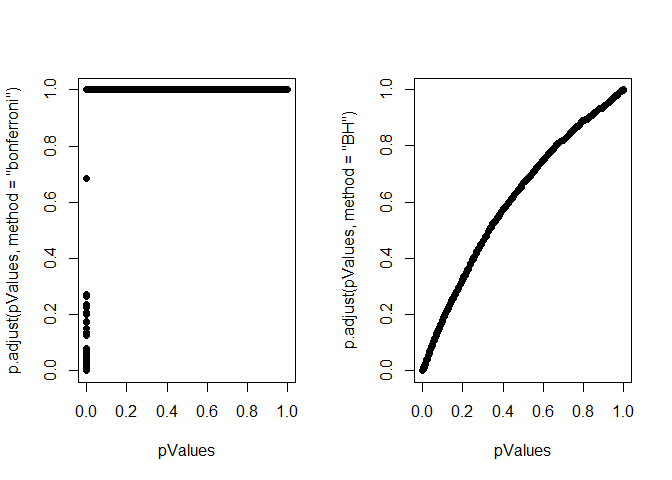

```r
par(mfrow=c(1,2))
plot(pValues, p.adjust(pValues, method="bonferroni"), pch=19)
plot(pValues, p.adjust(pValues, method="BH"), pch=19)
```

## Notes and resources

### Notes:

- Multiple testing is an entire subfield
- A basic Bonferroni/BH correction is usually enough
- If there is strong dependence between tests there may be problems
  - Consider `method="BY"`

### Further resources

- [Multiple testing procedures with applications to genomics](http://www.amazon.com/Multiple-Procedures-Applications-Genomics-Statistics/dp/0387493166/ref=sr_1_2/102-3292576-129059?ie=UTF8&s=books&qid=1187394873&sr=1-2)
- [Statistical significance for genome-wide studies](http://www.pnas.org/content/100/16/9440.full)
- [Introduction to multiple testing](http://ies.ed.gov/ncee/pubs/20084018/app_b.asp)